# Phase 5 AS

DISCLAIMER:

In terms of statistical inference, it could be argued that the act of creating training data serves as a sample sought to be representative of a different dataset - the Van Gogh letters. The F-Score metric evaluates the efficacy of this sample's performance in a comparable manner to a p-value - higher f-score means better performance, low p-value means statistical significance. The Platt scaling is used to obtain a confidence estimate of each classification - similarly to the idea of a confidence interval in normal statistical inference problems.

Thus, the majority of my statistical inference work is undertaken in the machine learning methodology portion of this project. However, I still use statistical methodology to discover and analyze results from my machine learning work, in line with existing research and nonlinear dynamics literature concerning the idea of Critical Slowing Down and early warning signs of phase change.

INTRODUCTION

The life of Vincent Van Gogh was fraught with trials and tribulations, resulting in emotional chaos and a progressive degradation in mental health. Following his 1890 suicide, numerous letters written by Van Gogh were preserved. These letters provide intimate insight into the inner-workings of the painter’s mind. Machine learning allows for the derivation of quantitative data from qualitative sources. Analyzing Van Gogh’s letters with machine learning allows for a nuanced understanding of the development of Van Gogh’s suicidality, while upholding the methodological foundations of sentiment analysis in application to quantitative psychology.

The general aim of my research is to provide new insight into the life of Vincent Van Gogh, while affirming the practicality and efficacy of a quantitative and statistical technique using sentiment analysis, the automated classification of emotion in text. Though most of the methodology is highly mathematical in nature, applications of the work exist in fields such as psychology, marketing, and sociology. The technique allows for the transformation of qualitative data into quantitative data, enabling the collection of numerical data from a wider array of sources.

More specifically, my work delves into the inner workings of Van Gogh’s mind through mathematical analysis of the Van Gogh letters - which will eventually be coupled with qualitative analysis of the development of Van Gogh’s art style as well as the exploration of historical documents to affirm the psychological findings of the sentiment analysis. Thus, the project combines mathematical modeling with quantitative psychology and art history to provide both a greater understanding of the life and psyche of Vincent Van Gogh, but also of the mechanistic process of suicide itself.

I hypothesize that machine learning can be used to create a quantitative dataset from a qualitative one, and that statistical inference via the utilization of metrics such as skewness, kurtosis, and autocorrelation can demonstrate a statistically significant effect.

METHODS:

Twitter is a social media networking site where users can post 280-character messages, called tweets. These tweets are commonly accompanied by hashtags which are used as a self-categorization of the emotions or subjects contained therein. The hashtag used in a tweet often indicates the topic of a tweet or the emotions felt by the author. Its popularity amongst members of various demographic groups, combined with the the high volume of tweets produced each and every day (Mohammad 2012), makes it a natural tool for collecting training data. Furthermore, the usage of hashtags allows researchers to obtain self-classified data, enabling more efficient and accurate data collection.

Hashtags were found for each of the eight variables. However, due to the binary nature of most of the classification algorithms, opposite characteristics (with opposite valence) were established for all of the variables if not already included in the dataset. For example, a control characteristic called ”happiness” was established as an opposite for characteristics such as ”desire for death”, or ”acquired capability”.

Establishing an opposite for each variable allows for the avoidance of more complex procedures and enables more realistic outputs. In the context of identifying potentially suicidal individuals, a binary classification scheme is logical given the natural overlap between characteristics. Classification of one characteristic against all other characteristics is considerably more arduous than a simple binary classification. This stems from the fact that multi-class problems classify items in a “one versus rest” structure, whereas binary classification problems are solely concerned with “one versus one” (Bishop, 2006).

Treating the characteristic emotions as binary becomes even more critical when considering the potential overlap between characteristics emotions that are not clear opposites. Text may also exhibit more than one characteristic, which a binary classification system allows for when opposite or control variables are introduced. Classification in a standard “one vs all”, or multi-class system additionally does not easily allow for interlocking classes or interdependent probabilities (Kourdi, 2004).

Count vectorization, also known as a “bag of words” model, creates a matrix containing all of the words in a corpus and counts the number of times each term occurs in the matrix (L ̈ubbering, 2018). This method is often unable to analyze complicated relationships within phrases, but by using a built-in “ngram” parameter provided by sklearn, a solution to this problem is provided by grouping phrases of an optimal length together. (Pedregosa 2011).

The f-score is a measure of algorithm performance that is not susceptible to bias due to unbalanced classes. Whereas a simple score such as proportion of correct classifications (ie "accuracy") may be biased by data with unequal sizes of the two classes, the f-score provides a robust score of binary classifier accuracy. The f-score is defined as the harmonic mean of precision and recall. Precision is a measure of true positive class predictions, whereas recall is a measure of the ratio of true positive class predictions to total positive class data. Thus, f-score provides a metric roughly analogous in application to p-values and a metric based in the idea of Type I and Type II errors.

SUPPORT VECTOR MACHINES:

Results and Discussions

Obtaining raw output values from the sentiment analysis models is only one step in the process of performing a proper quantitative analysis. Since the aim is to study the life of Vincent Van Gogh, particularly his suicide, through the lens of mathematical modelling, further statistical analysis is necessary.

Critical slowing down, though a predictor of suicide, can be difficult to detect. Studies in the fields of nonlinear dynamics show that statistical metrics such as autocorrelation, kurtosis, and skew are metrics serving as an early warning sign of critical showing down - or, in this context, of suicide (Lenton, 2012). Thus, a spike in the autocorrelation, kurtosis, or skew of an emotion over time serves as an early warning sign of suicidality. Simultaneous spikes in two or more of the metrics increase the likelihood of impending phase change dramatically by backing the validity of the predictive power of each metric.

I collected a corpus of more than 900 letters written by Van Gogh, and ran this dataset through my model. Each paragraph in the letters counts as a datapoint. I used a rolling autocorrelation function to analyze the dynamics of the emotions over time, looking for spikes in autocorrelation that would be indicative of critical slowing down.

I then familiarized myself with scholarly accounts of Vincent Van Gogh’s life so as to provide nuanced commentary regarding the overlap between my quantitative research and the qualitative fact.

The following charts provide some insight into the preliminary work that I have conducted thus far for this project.

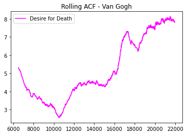

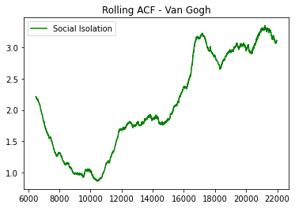

Further results and discussion is provided in the annotated code. The most important conclusion from the annotated code which may not be explicitly stated is that the historgrams, kurtosis, and skewness plots combine to show evidence of utilization of statistical inference and statistical methodology backed by nonlinear dynamics in addition to scholarly work concerning Van Gogh's life.

CONCLUSION:

Analyzing suicidality at an individual or even population level is incredibly difficult due to a myriad of legal, ethical, and logistical barriers. The entire project was born out of a weakness of a traditional discipline. Though psychology, through the subfield of suicidology, enabled the theoretical groundwork for this project, examining the validity of psychological theory of suicide in practice was difficult due to the multitude of ethical, logistical, and legal barriers preventing the necessary experiments or data acquisition. Thus, in order to get data to evaluate the veracity of the psychological theory - namely that critical slowing down serves as an early warning to suicide - another discipline had to be introduced.

I then used sentiment analysis as a complementary research tool, enabling me to further study the psychology of suicide through a mathematical lens. Sentiment analysis and machine learning offer tools to blunt the difficulty posed by the problem of studying suicide by allowing for the conversion of qualitative data into quantitative data usable for time series analysis and other forms of quantitative methodology. This approach was admittedly far from perfect - assigning a quantitative score to something as complex as writing is reductive. However, any sort of modeling is, by definition, reductive. The sentiment analysis approach was the most feasible and cleanest possible solution given legal and ethical constraints barring other forms of data collection.

My methodology demonstrated both utilization of a vast array of statistical techniques and approaches to statistical inference, but also meaningful results that align with scholarly work concerning the life of Vincent Van Gogh. The insight afforded to us through the use of sentiment analysis provides a valuable lens into the mindset and life of the famed artist.

The procedures demonstrated in this paper are applicable to a vast array of problems, such as evaluating product reviews in market research, detecting radicalization over time on social media, or as a means to create data for mathematical models requiring validation.

FUTURE WORKS:

In the future, I plan to work with the dataset of sentiment analysis to correlate colors from Van Gogh paintings with fluctuations in emotions from the letters. I plan to work with a philosophy of art professor, Dr. Jessica Logue, to publish the results on Van Gogh's emotional state as well as analysis of the corresponding art in an aesthetics journal or public philosophy journal.

```python
APPENDIX A: ANNOTATED CODE WITH EXPLANATIONS
```

The report will contain an explanation of the code, followed by a brief write-up tying up loose ends.

The following section imports necessary packages, utilized later in the code.

```python
import pandas as pd #pd becomes shortcut for pandas
import numpy as np
import matplotlib.pyplot as plt

import pickle #downloading stuff to make gui packaged


import os

from sklearn.metrics import classification_report,confusion_matrix
from sklearn.model_selection import train_test_split

from sklearn import preprocessing
#data = pd.read_csv('cd parler.csv') #alternative dataset
```

Importing the dataset into python, using pandas to read the training data dataset. Importing a few more sklearn metrics packages that will be implemented later.

Dropping the "author" column in the data to make the training data anonymous, mostly for ethical reasons.

Then, selecting the classification scheme to train the model on by commmenting out the "data.drop" for the two emotions or sentiments to be classified against each other.

```python
data = pd.read_csv('gv train.csv')

#data = pd.read_csv('ape train.csv')
#, encoding='latin1'


from sklearn.metrics import accuracy_score
from sklearn.metrics import f1_score
from sklearn.cluster import SpectralClustering
from sklearn.preprocessing import OneHotEncoder
from sklearn.compose import ColumnTransformer
from numpy import array

data = data.drop('author', axis=1) # axis = 1 makes it col instead of row

# #%%




# #comment out the two data labels you want to run the classification algorithm with

data = data.drop(data[data.sentiment == 'control'].index)
data = data.drop(data[data.sentiment == ' control'].index) #typo. too lazy to fix it for now.
data = data.drop(data[data.sentiment == 'desire for death'].index)
data = data.drop(data[data.sentiment == 'acquired capability'].index)
data = data.drop(data[data.sentiment == 'drug alcohol'].index)
data = data.drop(data[data.sentiment == 'social connection'].index)
data = data.drop(data[data.sentiment == 'social isolation'].index)
data = data.drop(data[data.sentiment == 'anger'].index)
#data = data.drop(data[data.sentiment == 'happiness'].index)
data = data.drop(data[data.sentiment == 'sadness'].index)
#data = data.drop(data[data.sentiment == 'stress'].index)
data = data.drop(data[data.sentiment == ' '].index) #if blanks aren't deleted
#%% terriorism
data = data.drop(data[data.sentiment == 'resentment'].index) #make sure that both of these are commented out if classifying for love
data = data.drop(data[data.sentiment == 'narcissism'].index)
data = data.drop(data[data.sentiment == 'threat'].index)
data = data.drop(data[data.sentiment == 'social alienation'].index)
data = data.drop(data[data.sentiment == 'positive'].index)
data = data.drop(data[data.sentiment == 'strong negative'].index)
data = data.drop(data[data.sentiment == 'hopelessness'].index)
data = data.drop(data[data.sentiment == 'fear'].index)
```

Encode and split training and testing data. This has been rigorously tested for data leakage and follows the docs.

This is a good section in which to consider the nature of my training data.

DATA EXPlORATION - PT. 1

Desire for death: (5,859 tweets in dataset) • #suicidal • #hopeless • #hopelessness • #depressed • #selfharm

```python
y = data.sentiment.values
lbl_enc = preprocessing.LabelEncoder()
X_train, X_val, y_train, y_val = train_test_split(data.content.values, y, stratify=y, random_state=11, test_size=0.2, shuffle=True)
y = lbl_enc.fit_transform(data.sentiment.values)
# rng=RandomState()

# # train = data.sample(frac=0.8, random_state=rng)
from sklearn import preprocessing  #no data leakage from this. I've checked, plus there's no reason for there to be data leakage.
#lbl_enc = preprocessing.LabelEncoder()

#y = lbl_enc.fit_transform(data.sentiment.values)

from sklearn import preprocessing
```

Playing around with some module settings such that I can use platt scaling later on to transform discrete data into continuous data on a 0 to 1 scale, essentially using a confidence estimate derived from distance to decision boundary.

Doing some basic data cleaning by removing nontext characters, as well as removing stopwords that are unimportant to the data.

```python
data.to_csv("clean data.csv", index=True) #getting predict proba numbers to show up in c
#%%
#making everything lowercase using built in nltk
data['content'] = data['content'].apply(lambda x: " ".join(x.lower() for x in str(x).split()))
#removing punctuation
data['content'].apply(lambda x: " ".join(x.lower() for x in x.split()))
data['content'] = data['content'].str.replace('[^\w\s]',' ')
#deleting stop words; they, then, that, words that have no meaning
from nltk.corpus import stopwords #if this fails, you gotta redownload stopwords and restart kernel.
stop = stopwords.words('english')
data['content'] = data['content'].apply(lambda x: " ".join(x for x in x.split() if x not in stop))

freq = pd.Series(' '.join(data['content']).split()).value_counts()[-1000:]

# removing super rare words
freq = list(freq.index)
data['content'] = data['content'].apply(lambda x: " ".join(x for x in x.split() if x not in freq))
```

Count vectorize the words in the training dataset. I considered using TF-IDF, but I wasn't seeing as good performance so I decided to go with a dumber means of vectorizing the words.

```python
#print(data.sentiment.values) #this is here to catch anything that isn't filtered - ie stupid typos i make


#  #%%
# #getting TF-IDF parameters
# from sklearn.feature_extraction.text import TfidfVectorizer
# tfidf = TfidfVectorizer(max_features=1000, analyzer='word',ngram_range=(1,3))
# X_train_tfidf = tfidf.fit_transform(X_train.astype("U"))
# X_val_tfidf = tfidf.fit_transform(X_val.astype("U"))
# # X_val_tfidf = tfidf.fit_transform(X_val)

# # getting count Vectors Parameters - works much better.
from sklearn.feature_extraction.text import CountVectorizer
count_vect = CountVectorizer(analyzer='word')
count_vect.fit(data['content'])
X_train_count = count_vect.transform(X_train.astype('U'))
X_val_count =  count_vect.transform(X_val.astype("U"))
```

Testing a bunch of models to see which one boasts the best performance.

The models tested are:

1.Multinomial Naive Bayes classifier

2.Linear Support Vector machine using stochastic gradient descent as an optimization algorithm.

3.Stochastic gradient descent classifier

4.Logistic regression classifier

5.Random forest classfier

6.Several support vector classifiers, which are essentially SVMs but with a nu parameter which allows for effectively a sensitivity element by specifying numbers of support vectors used to create the canonical hyperplane.

```python
# Testing phase


# # multinomial naive bayes which is innacurate.

# from sklearn.naive_bayes import MultinomialNB
# nb = MultinomialNB()
# nb.fit(X_train_tfidf, y_train)
# y_pred = nb.predict(X_val_tfidf)
# print('naive bayes tfidf accuracy %s' % accuracy_score(y_pred, y_val))
#
#from sklearn.metrics import classification_report,confusion_matrix
#print(confusion_matrix(y_val, y_pred))
# #
# # Linear SVM which also doesn't work

# from sklearn.linear_model import SGDClassifier
# lsvm = SGDClassifier(alpha=0.001, random_state=5, max_iter=15, tol=None)
# lsvm.fit(X_train_tfidf, y_train)
# y_pred = lsvm.predict(X_val_tfidf)
# print('svm using tfidf accuracy %s' % accuracy_score(y_pred, y_val))
# #
# #
# #
# ## logistic regression (ignore the warning)
#
# from sklearn.linear_model import LogisticRegression
# logreg = LogisticRegression(C=1)
# logreg.fit(X_train_tfidf, y_train)
# y_pred = logreg.predict(X_val_tfidf)
# print('log reg tfidf accuracy %s' % accuracy_score(y_pred, y_val))

# #
# # svr

## random forest classifier

# from sklearn.ensemble import RandomForestClassifier
# rf = RandomForestClassifier(n_estimators=500)
# rf.fit(X_train_tfidf, y_train)
# y_pred = rf.predict(X_val_tfidf)
# print('random forest tfidf accuracy %s' % accuracy_score(y_pred, y_val))
# ##
# #%%
# # # #Multinomial Naive Bayes Classifier with count vector (much better but not the best)
# from sklearn.naive_bayes import MultinomialNB
# nb = MultinomialNB()
# nb.fit(X_train_count, y_train)
# y_pred = nb.predict(X_val_count)
# print('naive bayes count vectors accuracy %s' % accuracy_score(y_pred, y_val))
# print('naive bayes count vectors f score weighted %s' %f1_score(y_pred, y_val, average='weighted'))
# #


#%%
#Linear SVM with count vector - sgd
# from sklearn.linear_model import SGDClassifier
# lsvm = SGDClassifier(alpha=0.001, random_state=5, max_iter=15, tol=None, loss ='squared_hinge')
# lsvm.fit(X_train_count, y_train)
# y_pred = lsvm.predict(X_val_count)
# print('lsvm using count vectors accuracy %s' % accuracy_score(y_pred, y_val))
# print('lsvm using count vectors f score weighted %s' %f1_score(y_pred, y_val, average='weighted'))
# print('lsvm using count vectors f score micro %s' %f1_score(y_pred, y_val, average='micro'))
# print('lsvm using count vectors f score macro %s' %f1_score(y_pred, y_val, average='macro'))

# print(confusion_matrix(y_val, y_pred))
# # print(confusion_matrix(y_val, y_pred))
# # ##%% logit count vector
# # #
# from sklearn.linear_model import LogisticRegression
# logreg = LogisticRegression(penalty='l2', dual=False, tol=0.0001, C=1.0, solver='lbfgs', multi_class='ovr', max_iter=170)
# logreg.fit(X_train_count, y_train)
# y_pred = logreg.predict(X_val_count)
# print('log reg count vectors accuracy %s' % accuracy_score(y_pred, y_val))
# print('log reg using count vectors accuracy %s' % accuracy_score(y_pred, y_val))
# print('log red using count vectors f score weighted %s' %f1_score(y_pred, y_val, average='weighted'))
# print('log reg using count vectors f score micro %s' %f1_score(y_pred, y_val, average='micro'))
# print('log reg using count vectors f score macro %s' %f1_score(y_pred, y_val, average='macro'))
#%%
# # from sklearn.linear_model import LogisticRegression
# # logreg = LogisticRegression(penalty='l2', dual=False, tol=0.0001, C=1.0, solver='newton-cg', multi_class='ovr', max_iter=170)
# # logreg.fit(X_train_count, y_train)
# # y_pred = logreg.predict(X_val_count)
# # print('log reg count vectors accuracy %s' % accuracy_score(y_pred, y_val))
# # print('log reg using count vectors accuracy %s' % accuracy_score(y_pred, y_val))
# # print('log red using count vectors f score weighted %s' %f1_score(y_pred, y_val, average='weighted'))
# # print('log reg using count vectors f score micro %s' %f1_score(y_pred, y_val, average='micro'))
# # print('log reg using count vectors f score macro %s' %f1_score(y_pred, y_val, average='macro'))
#%%
# from sklearn.linear_model import LogisticRegression
# lsvm = LogisticRegression(penalty='l2', dual=False, tol=0.0001, C=1.0, solver='saga', multi_class='ovr', max_iter=170)
# lsvm.fit(X_train_count, y_train)
# y_pred = lsvm.predict(X_val_count)
# print('log reg count vectors accuracy %s' % accuracy_score(y_pred, y_val))
# print('log reg using count vectors accuracy %s' % accuracy_score(y_pred, y_val))
# print('log red using count vectors f score weighted %s' %f1_score(y_pred, y_val, average='weighted'))
# print('log reg using count vectors f score micro %s' %f1_score(y_pred, y_val, average='micro'))
# print('log reg using count vectors f score macro %s' %f1_score(y_pred, y_val, average='macro'))

# #%%
# # don't uncomment
# ##plt.scatter(X_train, y_pred)
# ##plt.show()
# ##





# #%% radial basis function with support vector classifier

# from sklearn.svm import NuSVC #dont touch nu please
# lsvm = NuSVC(nu=0.05, kernel='rbf', degree=3, gamma='scale', coef0=0.0, shrinking=True, probability=True, tol=0.001, cache_size=200, class_weight=None, verbose=False, max_iter=-1, decision_function_shape='ovr', random_state=None)
# lsvm.fit(X_train_count, y_train)
# y_pred = lsvm.predict(X_val_count)
# print('svcusing count vectors with rbf accuracy %s' % accuracy_score(y_pred, y_val))
# print('svc rbf kernel using count vectors accuracy %s' % accuracy_score(y_pred, y_val))
# print('svc rbf kernel using count vectors f score weighted %s' %f1_score(y_pred, y_val, average='weighted'))
# print('svc rbf kernel using count vectors f score micro %s' %f1_score(y_pred, y_val, average='micro'))
# print('svc rbf kernel using count vectors f score macro %s' %f1_score(y_pred, y_val, average='macro'))

# filename = 'social.model'
# pickle.dump(lsvm, open(filename, 'wb'))

#vec_file = 'vsocial.pickle'
#pickle.dump(count_vect, open(vec_file, 'wb'))

#loadedvsocial = pickle.load(open('vsocial.pickle', 'rb')) #vector
#loadedsocial = pickle.load(open('social.sav', 'rb')) #model
#loadedvsocial = loadedvsocial(lowercase=False)
# # probability_class_1 = SVC.predict_proba(X_train_count)
# # #print(confusion_matrix(y_val, y_pred))
# # # #%% support vector classifier - polynomial kernel

# from sklearn.svm import NuSVC #if you touch nu I will hunt you down.
# SVC = NuSVC(nu=0.1, kernel='poly', degree=3, gamma='scale', coef0=0.0, shrinking=True, probability=True, tol=0.001, cache_size=200, class_weight=None, verbose=False, max_iter=-1, decision_function_shape='ovr', random_state=None)
# SVC.fit(X_train_count, y_train)
# y_pred = SVC.predict(X_val_count)

# print('svc using polynomial kernel using count vectors accuracy %s' % accuracy_score(y_pred, y_val))
# print('svc poly kernel using count vectors accuracy %s' % accuracy_score(y_pred, y_val))
# print('svc poly kernel using count vectors f score weighted %s' %f1_score(y_pred, y_val, average='weighted'))
# print('svc poly kernel using count vectors f score micro %s' %f1_score(y_pred, y_val, average='micro'))
# print('svc poly ernel using count vectors f score macro %s' %f1_score(y_pred, y_val, average='macro'))

#probability_class_1 = SVC.predict_proba(X_train_count)

# #print(confusion_matrix(y_val, y_pred))

# #%%
# ###nearest neighbor with count
# # from sklearn.neighbors import KNeighborsClassifier
# # neigh = KNeighborsClassifier(n_neighbors=3)
# # neigh.fit(X_train_count, y_train)
# # y_pred = neigh.predict(X_val_count)
# # print('nn count accrucacy %s' % accuracy_score(y_pred, y_val))
# # print('nn using count vectors f score weighted %s' %f1_score(y_pred, y_val, average='weighted'))
# # print('nn using count vectors f score micro %s' %f1_score(y_pred, y_val, average='micro'))
# # print('nn using count vectors f score macro %s' %f1_score(y_pred, y_val, average='macro'))


# # #print(confusion_matrix(y_val, y_pred))

# #%% linear kernel classifier

# # from sklearn.svm import NuSVC
# # SVCl = NuSVC(nu=0.1, kernel='linear', degree=3, gamma='scale', coef0=0.0, shrinking=True, probability=False, tol=0.001, cache_size=200, class_weight=None, verbose=False, max_iter=-1, decision_function_shape='ovr', random_state=None)
# # SVCl.fit(X_train_count, y_train)
# # y_pred = SVCl.predict(X_val_count)
# # print('svc usnig linear kernel using count vectors accuracy %s' % accuracy_score(y_pred, y_val))
# # print('svc lin kernel using count vectors accuracy %s' % accuracy_score(y_pred, y_val))
# # print('svc lin kernel using count vectors f score weighted %s' %f1_score(y_pred, y_val, average='weighted'))
# # print('svc lin kernel using count vectors f score micro %s' %f1_score(y_pred, y_val, average='micro'))
# # print('svc link ernel using count vectors f score macro %s' %f1_score(y_pred, y_val, average='macro'))


# # print(confusion_matrix(y_val, y_pred))


# #%% sigmoid kernel support vector classifier

# # from sklearn.svm import NuSVC #dont touch nu
# # SVC = NuSVC(nu=0.4, kernel='sigmoid', degree=3, gamma='scale', coef0=0.0, shrinking=True, probability=True, tol=0.001, cache_size=200, class_weight=None, verbose=False, max_iter=-1, decision_function_shape='ovr', random_state=None)
# # SVC.fit(X_train_count, y_train)
# # y_pred = SVC.predict(X_val_count) # reset variables in the console when switching emotions
# # print('svc using sigmoid count vector accuracy %s' % accuracy_score(y_pred, y_val))
# # print('svc sig kernel using count vectors accuracy %s' % accuracy_score(y_pred, y_val))
# # print('svc sig kernel using count vectors f score weighted %s' %f1_score(y_pred, y_val, average='weighted'))
# # print('svc sig kernel using count vectors f score micro %s' %f1_score(y_pred, y_val, average='micro'))
# # print('svc sig kernel using count vectors f score macro %s' %f1_score(y_pred, y_val, average='macro'))
# # distance_to_decision_boundary = SVC.decision_function(X_train_count)
# # probability_class_1 = SVC.predict_proba(X_train_count)
# # #[:, 1]

# # # folder = 'trained_models/happy_sad' #might not work for you if ur dir is weird

# # #joblib.dump(SVC_saved, folder)
# # SVC_saved = joblib.load('trained_models/happy_sad')





# #%% fetching support vectors

# # support_vector_indices = lsvm.support
# # print(support_vector_indices)



# #%% random forest count vector (takes forever)

# # from sklearn.ensemble import RandomForestClassifier
# # rf = RandomForestClassifier(n_estimators=500)
# # rf.fit(X_train_count, y_train)
# # y_pred = rf.predict(X_val_count)
# # print('random forest with count vectors accuracy %s' % accuracy_score(y_pred, y_val))
# # print('rf using count vectors accuracy %s' % accuracy_score(y_pred, y_val))
# # print('rf using count vectors f score weighted %s' %f1_score(y_pred, y_val, average='weighted'))
# # print('rf using count vectors f score micro %s' %f1_score(y_pred, y_val, average='micro'))
# # print('rf using count vectors f score macro %s' %f1_score(y_pred, y_val, average='macro'))


from sklearn.svm import NuSVC #if you touch nu I will hunt you down.
SVC = NuSVC(nu=0.1, kernel='poly', degree=3, gamma='scale', coef0=0.0, shrinking=True, probability=True, tol=0.001, cache_size=200, class_weight=None, verbose=False, max_iter=-1, decision_function_shape='ovr', random_state=None)
SVC.fit(X_train_count, y_train)
y_pred = SVC.predict(X_val_count)

print('svc using polynomial kernel using count vectors accuracy %s' % accuracy_score(y_pred, y_val))
print('svc poly kernel using count vectors accuracy %s' % accuracy_score(y_pred, y_val))
print('svc poly kernel using count vectors f score weighted %s' %f1_score(y_pred, y_val, average='weighted'))
print('svc poly kernel using count vectors f score micro %s' %f1_score(y_pred, y_val, average='micro'))
print('svc poly ernel using count vectors f score macro %s' %f1_score(y_pred, y_val, average='macro'))

probability_class_1 = SVC.predict_proba(X_train_count)
```

```
svc using polynomial kernel using count vectors accuracy 0.8305785123966942
svc poly kernel using count vectors accuracy 0.8305785123966942
svc poly kernel using count vectors f score weighted 0.8304927785063342
svc poly kernel using count vectors f score micro 0.8305785123966943
svc poly ernel using count vectors f score macro 0.8293609680297712
```

After the step earlier, the training is done.

Now, I upload the data we actually want to use, which is the dataset of Van Gogh letters. Then, we go through the same preprocessing and processing steps, classify the letters with our model that was trained above, and save the output in a file so that we can go through all the classification schemes for every letter.

```python
tweets = pd.read_csv('vg2.0.csv')

#pulling count vectors from tweets
poem1 = pd.DataFrame(tweets) #vars are to convert data type
poem2 = poem1['content']
poem3 = [poem2] #converting to iterable over raw text, instead of just string
poem_count = count_vect.transform(poem1['content'])

#evaluate test sentences with lsvm
SVC_pred = SVC.predict(poem_count)
print('lsvm predictions %s' % (SVC_pred))
poem_confidence = SVC.predict_proba(poem_count)

confidence = poem_confidence #change this for different metric

df = pd.DataFrame(data=X_train)
df = pd.DataFrame(poem_count)
confidence.astype(np.int64)
df2 = pd.DataFrame(data=confidence) #isotonic regression

#distance = distance_to_decision_boundary
df_platt = pd.concat([poem1['content'], df2], axis=1) #this is the data frame you wanna look at.
```

```
lsvm predictions ['happiness' 'happiness' 'happiness' ... 'happiness' 'happiness'
 'happiness']
```

This is the start of the data analysis - even though this entire project is thoroughly statistical analysis.

I'm following literature showing that spikes in autocorrelation are associated with something called critical slowing down, which is a marker of phase change. In line with a paper by Dutch scientist van de Leemput, suicide can be predicted by critical slowing down as suicide can be studied as a dynamic system with stable states.

```python
import matplotlib.pyplot as plt


#data = pd.read_csv('avgletters.csv')

data = pd.read_csv('realdata.csv')
```

Filtering by location and letter recipient selected in the analysis. This allows me to study specific subsets of the dataset as well as specific eras in Van Gogh's life.

```python
#%% LOCATION.


#data = data.loc[data['place'] == 'Antwerp']
#data = data.loc[data['place'] == 'Amsterdam']
#data = data.loc[data['place'] == 'Arles']
#data = data.loc[data['place'] == 'Auvers']
#data = data.loc[data['place'] == 'Brussels']
#data = data.loc[data['place'] == 'Cuesmes']
#data = data.loc[data['place'] == 'Dordrecht']
#data = data.loc[data['place'] == 'Eindhoven']
#data = data.loc[data['place'] == 'Etten']
#data = data.loc[data['place'] == 'Helvoirt']
#data = data.loc[data['place'] == 'Hoogeveen']
#data = data.loc[data['place'] == 'Isleworth']
#data = data.loc[data['place'] == 'Laken']
#data = data.loc[data['place'] == 'Les Saintes-Maries-de-la-Mer']
#data = data.loc[data['place'] == 'London']
#data = data.loc[data['place'] == 'Nieuw-Amsterdam']
#data = data.loc[data['place'] == 'Nuenen']
#data = data.loc[data['place'] == 'Paris']
#data = data.loc[data['place'] == 'Ramsgate']
#data = data.loc[data['place'] == 'Saint-Rmy']
#data = data.loc[data['place'] == 'The Hague']
#data = data.loc[data['place'] == 'Wasmes']
#data = data.loc[data['place'] == 'Welwyn']



### DRENTHE = HOOGEVEN and NIEUW AMSTERDAM



#%% RECIPIENT

#data = data.loc[data['recipient'] == 'Theo van Gogh']
# data = data.loc[data['recipient'] == 'Albert Aurier']
# data = data.loc[data['recipient'] == 'Anna van Gogh']
# data = data.loc[data['recipient'] == 'Anthon van Rappard']
# data = data.loc[data['recipient'] == 'Antoine Philippe Furne']
# data = data.loc[data['recipient'] == 'Anton Kerssemakers']
#data = data.loc[data['recipient'] == 'Arnold Koning']
# data = data.loc[data['recipient'] == 'Betsy Terseeg']
# data = data.loc[data['recipient'] == 'Caroline van Stockum']
# data = data.loc[data['recipient'] == 'Charles Angrand']
# data = data.loc[data['recipient'] == 'Cornelis Marinus van Gogh']
# data = data.loc[data['recipient'] == 'Egbert Borchers']
# data = data.loc[data['recipient'] == 'Emile Bernard']
# data = data.loc[data['recipient'] == 'Eugene Boch']
# data = data.loc[data['recipient'] == 'Hendrik Jan Furne']
# data = data.loc[data['recipient'] == 'Hendrik Verzijl']
# data = data.loc[data['recipient'] == 'Hermanus Gijsbertus Tersteeg']
# data = data.loc[data['recipient'] == 'Horace Mann Livens']
# data = data.loc[data['recipient'] == 'Jo Van Gogh-Bonger']
# data = data.loc[data['recipient'] == 'Johannes van Hombergh']
# data = data.loc[data['recipient'] == 'John Peter Russell']
# data = data.loc[data['recipient'] == 'Joseph and Marie Ginoux']
# data = data.loc[data['recipient'] == 'Joseph Ginoux']
# data = data.loc[data['recipient'] == 'Joseph Jacob Isaacson']
# data = data.loc[data['recipient'] == 'Michiel Antonie de Zwart']
#data = data.loc[data['recipient'] == 'Octave Maus']
#data = data.loc[data['recipient'] == 'Paul Gauguin']
# data = data.loc[data['recipient'] == 'Paul Signac']
# data = data.loc[data['recipient'] == 'Unknown']
# data = data.loc[data['recipient'] == 'Willem Stockum-Haanebeek']
# data = data.loc[data['recipient'] == 'Willemien van Gogh']
```

```python
des = data.filter(['desire for death'])
acq = data.filter(['acquired capability'])
iso = data.filter(['social isolation'])
ang = data.filter(['anger'])
subs = data.filter(['drug alc'])
hap = data.filter(['happiness'])
stre = data.filter(['stress'])
con = data.filter(['social connection'])
```

Calculating rolling skew for all of the variables - window is roughly 1/4th the data size which is consistent with existing literature.

```
array([[<AxesSubplot:title={'center':'social connection'}>]], dtype=object)
```

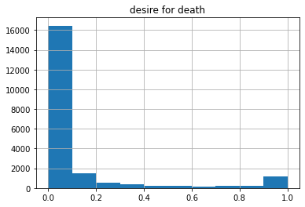

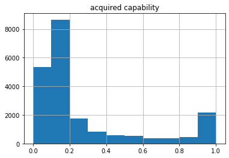

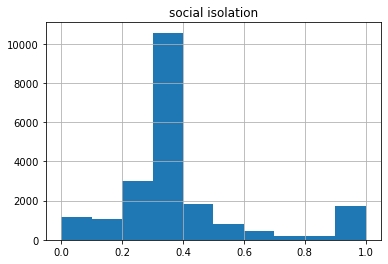

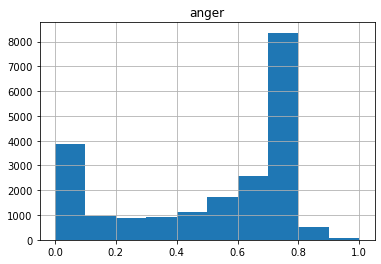

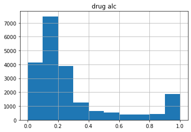

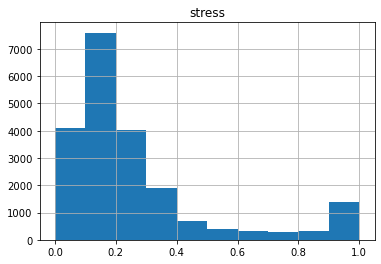

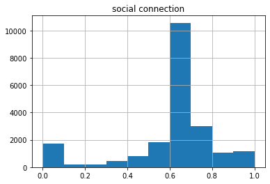

```python
des.hist()
acq.hist()
iso.hist()
ang.hist()
subs.hist()
#hap.hist()
stre.hist()
con.hist()
```

I'm using this as a bit of an aid to my inference - examining the distributions of the platt scaling value for my variables, or effectively examining the histogram of the Confidence estimate for all of my variables.

```python
ddes = des.rolling(5000).skew()
dacq = acq.rolling(5000).skew()
diso = iso.rolling(5000).skew()
dang = ang.rolling(5000).skew()
dsubs = subs.rolling(5000).skew()
dhap = hap.rolling(5000).skew()
dstre = stre.rolling(5000).skew()
dcon = con.rolling(5000).skew()

ddes1 = des.rolling(5000).kurt()
dacq1 = acq.rolling(5000).kurt()
diso1 = iso.rolling(5000).kurt()
dang1 = ang.rolling(5000).kurt()
dsubs1 = subs.rolling(5000).kurt()
dhap1 = hap.rolling(5000).kurt()
dstre1 = stre.rolling(5000).kurt()
dcon1 = con.rolling(5000).kurt()
```

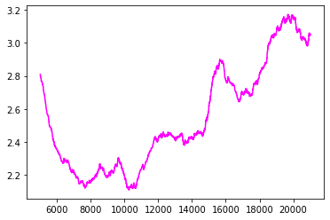

```python
plt.plot(
    ddes, color="fuchsia", label="Desire for Death Skewness"
    )
```

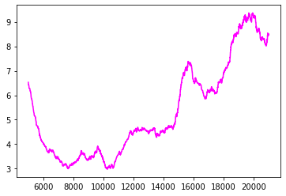

```python
plt.plot(
    ddes1, color="fuchsia", label="Desire for Death Kurtosis"
    )
```

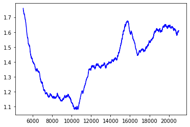

```python
#%%
plt.plot(
     dacq, color="blue", label="Acquired Capability Skewness"
     )
 #plt.title("Rolling Skewness - Acquired Capability: St. Remy")
```

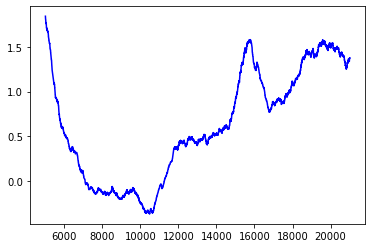

```python
plt.plot(
     dacq1, color="blue", label="Acquired Capability Kurtosis"
     )
```

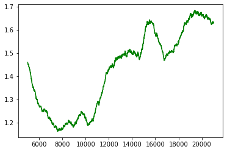

```python
# #%%
plt.plot(
     diso, color="green", label="Social Isolation Skewness"
     )
#%%
```

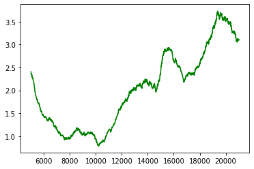

```python
plt.plot(
     diso1, color="green", label="Social Isolation Kurtosis"
     )
```

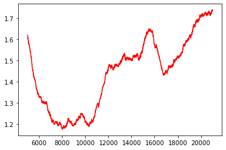

```python
# #%%
plt.plot(
     dsubs, color="red", label="Substance Abuse Skewness"
     )
```

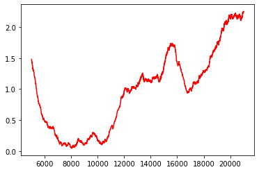

```python
plt.plot(
     dsubs1, color="red", label="Substance Abuse Kurtosis"
     )
```

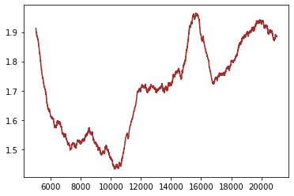

```python
plt.plot(
     dstre, color="brown", label="Stress"
     )
```

The charts above provide some insight into the preliminary work that I have conducted thus far for this project.

I believe that my intro provided insight into how these charts contribute to the understanding of Van Gogh's life.

I will attach files of data associated with this project along with this document.

WORKS CITED

Akman, O. (2011). Information complexity based modeling in the presence of length-biased sampled. Quality control and applied statistics, 56(1), 37-38.

Boettiger, C., Ross, N., & Hastings, A. (2013). Early warning signals: the charted and uncharted territories. Theoretical ecology, 6, 255-264.

Böken, B. (2021). On the appropriateness of Platt scaling in classifier calibration. Information Systems, 95, 101641.

Dakos, V., Kéfi, S., Rietkerk, M., Van Nes, E. H., & Scheffer, M. (2011). Slowing down in spatially patterned ecosystems at the brink of collapse. The American Naturalist, 177(6), E153-E166.

Lenton, T. M., Livina, V. N., Dakos, V., Van Nes, E. H., & Scheffer, M. (2012). Early warning of climate tipping points from critical slowing down: comparing methods to improve robustness. Philosophical Transactions of the Royal Society A: Mathematical, Physical and Engineering Sciences, 370(1962), 1185-1204.

Niculescu-Mizil, A., & Caruana, R. (2005, August). Predicting good probabilities with supervised learning. In Proceedings of the 22nd international conference on Machine learning (pp. 625-632).

Rueping, S. (2010). SVM classifier estimation from group probabilities. In Proceedings of the 27th international conference on machine learning (ICML-10) (pp. 911-918).

Schölkopf, B. (2000). The kernel trick for distances. Advances in neural information processing systems, 13.

Singley, A. (2022). Sentiment Analysis in Application to Behavior Prediction.

Smith, P. N., & Cukrowicz, K. C. (2010). Capable of suicide: A functional model of the acquired capability component of the interpersonal-psychological theory of suicide. Suicide and Life-Threatening Behavior, 40(3), 266-275.

Tan, Y., & Wang, J. (2004). A support vector machine with a hybrid kernel and minimal Vapnik-Chervonenkis dimension. IEEE Transactions on knowledge and data engineering, 16(4), 385-395.

Wichers, M., & Groot, P. C. (2016). Critical slowing down as a personalized early warning signal for depression. Psychotherapy and psychosomatics, 85(2), 114-116.

van de Leemput, I. A., Wichers, M., Cramer, A. O., Borsboom, D., Tuerlinckx, F., Kuppens, P., ... & Scheffer, M. (2014). Critical slowing down as early warning for the onset and termination of depression. Proceedings of the National Academy of Sciences, 111(1), 87-92.

Van Orden, K. A., Witte, T. K., Cukrowicz, K. C., Braithwaite, S. R., Selby, E. A., & Joiner Jr, T. E. (2010). The interpersonal theory of suicide. Psychological review, 117(2), 575.